# Introduction to Google Earth Engine for Ecologists and Practitioners

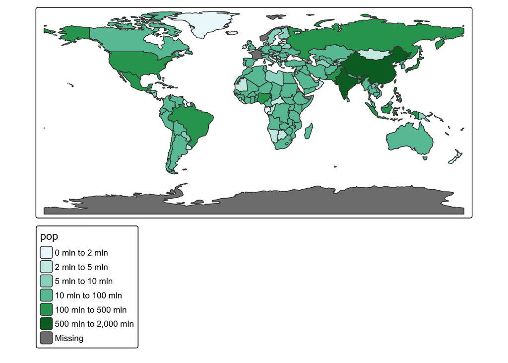

```r
breaks = c(0, 2, 5, 10, 100, 500, 2000) * 1000000 # customized breaks
tm_shape(world) + tm_polygons(fill = "pop", fill.scale = tm_scale(values = "brewer.bu_gn", breaks = breaks))
```

Finally, we need to make a good legend. This is controled by the argument `fill.legend` for the fill in which you can control the name, position, orientation, etc. Note that if you want to specify legends for other commands, you will need to use the proper argument (e.g., `lwd.legend`). Check the help to learn more.

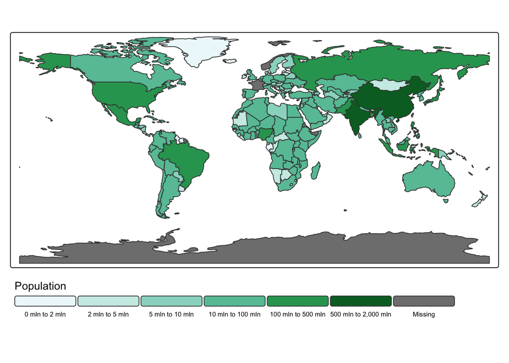

```r
tm_shape(world) +
  tm_polygons(fill = "pop", fill.scale = tm_scale(values = "brewer.bu_gn", breaks = breaks), fill.legend = tm_legend(
        title = "Population", orientation = "landscape",
        position = tm_pos_out("center", "bottom"), frame = FALSE
        ))
```

So far we have been editing the objects, but a good map needs other elements in the layout. These include title, scale bar, north arrow, any text, etc.

Additional elements such as north arrows and scale bars have their own functions: `tm_compass()` and `tm_scalebar()`. Here is an example on how to add the north arrow.

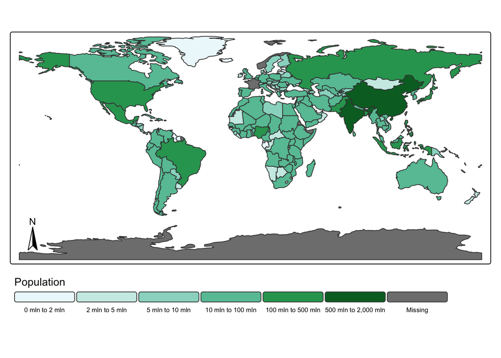

```r
tm_shape(world) +
  tm_polygons(fill = "pop", fill.scale = tm_scale(values = "brewer.bu_gn", breaks = breaks), fill.legend = tm_legend(
        title = "Population", orientation = "landscape",
        position = tm_pos_out("center", "bottom"), frame = FALSE
        )) +
  tm_compass(position = c("left", "bottom"))
```

#### 4.2.3 Interactive maps

It was cool to make animated maps, but we can now take maps to a new level with interactive maps. The release of the ‘leaflet’ package in 2015 revolutionized interactive web map creation from within R and a number of packages have built on it since then.

Here we will learn how to create interactive maps using tmaps. Tmaps has a unique function that allows to display your maps as static or interactive. The only caution is that certain features such as scale bars and north arrows are not displayed or used in interactive mode. It also has some limitations on the legends that can be created. But depending on the purpose, it is worth how much you gain.

All you need to do is switching to view mode, using the command `tmap_mode("view")`.

Lets display one of our previous maps on the interactive mode:

```r
tmap_mode("view")
```

```
## ℹ tmap mode set to "view".
```

```r
tm_shape(world) + tm_polygons(fill = "pop", fill.scale = tm_scale(values = "brewer.bu_gn", breaks = breaks), fill.legend = tm_legend(
        title = "Population"))
```

[interactive chart not shown]

You can navigate the map and click on each country to query the population size. You can also change the base map displayed. This type of map is displayed in html, and be saved as an html file to share or even to insert in your own website.

### 4.3 Creating your own high quality map.

First, lets load necessary packages:

```r
library(sf)
library(terra)
library(tidyverse)
library(tmap)
```

Now, we need to load the image and Shapefile we exported from GEE. Make sure to move all the files into the directory you are working in. You could set up a `googldrive` package to connect directly R to your repository, but we will keep it simple here. Download the files from your Google drive and move those files into the working directory you are using with R.

Note we use `st_read()` from the `sf` package to read a shapefile, and we use `rast()` from the `terra` package to read a raster file.

```r
PAs <- st_read("./Data/PAs.shp")
BurntA <- rast("./Data/BurntAreas.tif")
```

If you recall, we set all background pixels in the image in GEE to -9999. We need now to transform those values to NAs. We can do a simple plot to ensure the image is what we expect.

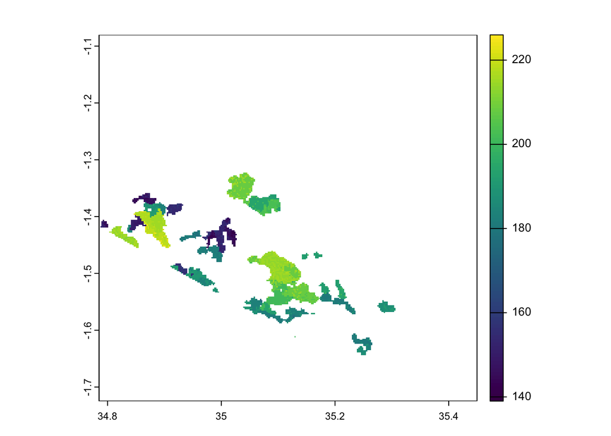

```r
BurntA[BurntA == -9999] <- NA
plot(BurntA)
```

Now, we have all we need to make a map. We will start with a static map.

```r
tmap_mode("plot")
```

```
## ℹ tmap mode set to "plot".
```

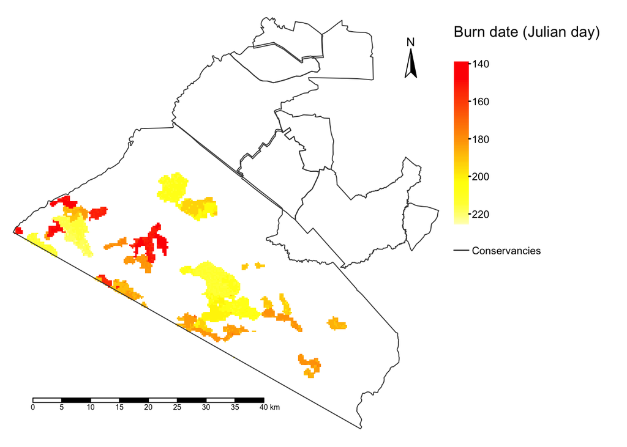

```r
tm_shape(BurntA) + tm_raster(col.scale = tm_scale_continuous(values = heat.colors(9)), col.legend = tm_legend( "Burn date (Julian day)")) +
  tm_shape(PAs) + tm_borders(lty = 1) +
  tm_compass(position = c("right", "top")) +
  tm_scalebar(position = c("left", "bottom"), width = 30) + tm_layout(frame = FALSE, legend.outside = T, legend.frame = F, legend.title.size = 1, legend.text.size = 0.7) + tm_add_legend(type = c("lines"), fill = c('black'), labels = c("Conservancies"))
```

And now interactive.

```r
tmap_mode("view")
```

```
## ℹ tmap mode set to "view".
```

```r
tm_shape(BurntA) + tm_raster(col.scale = tm_scale_continuous(values = heat.colors(9)), col.legend = tm_legend( "Burn date (Julian day)")) +
  tm_shape(PAs) + tm_borders(lty = 2)
```

[interactive chart not shown]

Bonus:

Add the chart using `tm_logo()`:

```r
tmap_mode("plot")
```

```
## ℹ tmap mode set to "plot".
```

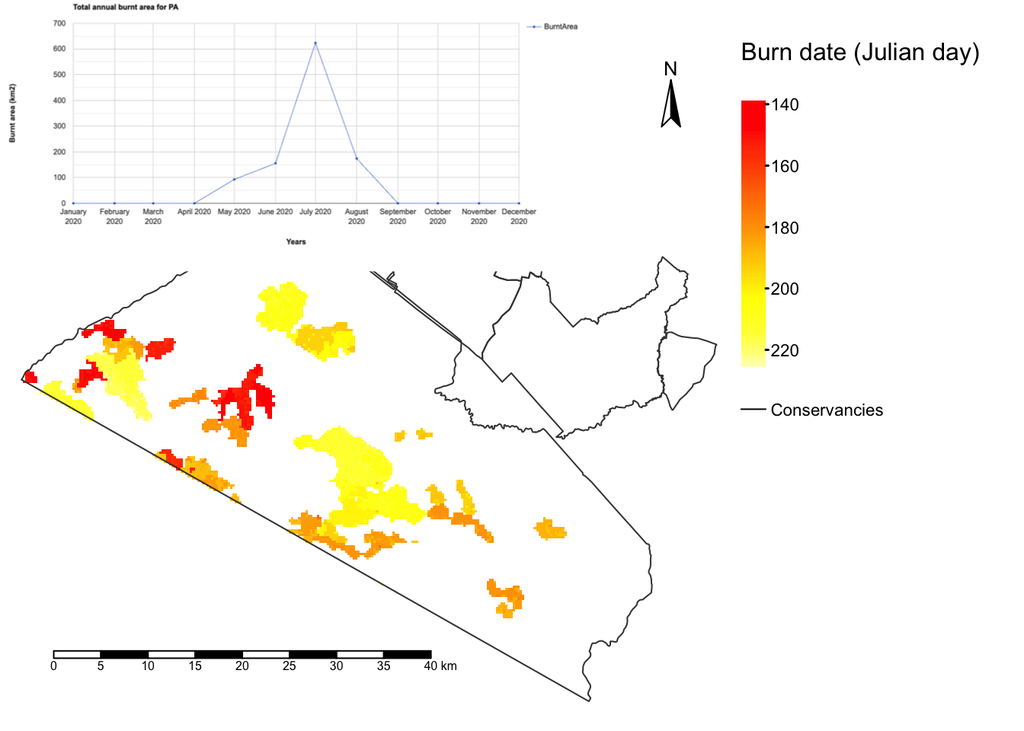

```r
tm_shape(BurntA) + tm_raster(col.scale = tm_scale_continuous(values = heat.colors(9)), col.legend = tm_legend( "Burn date (Julian day)")) +
  tm_shape(PAs) + tm_borders(lty = 1) +
  tm_compass(position = c("right", "top")) +
  tm_scalebar(position = c("left", "bottom"), width = 30) + tm_layout(frame = FALSE, legend.outside = T, legend.frame = F, legend.title.size = 1, legend.text.size = 0.7) + tm_add_legend(type = c("lines"), fill = c('black'), labels = c("Conservancies")) +
  tm_logo("FigCh3/ee-chart.png",
          height=11, position = c(-0.1,1.1))
```

### 4.4 Assignment 3

This activity is intended to practice the skills you have learned so far. What we want you to do now is to spend some time exploring different data sets available in GEE and practicing code. There are so many things to explore. Climatic data, Land Cover products, etc.

1. [Easy to moderate] Once you have an image that you are happy with, export it to your Google Drive for an area of interest.
2. [Difficult] Using the R code to make a map, try to create a nice map for your data.
3. [Difficult] Go back to GEE and create a set of points within your study area (Same you used to export the image). Export the points as a Shapefile to your Google Drive. Load the Shapefile to R, and extract the pixel values of the previously exported image to each point.